# Peer-graded Assignment: Course Project 1

Charles Champeaux

8 January 2018

## Introduction

It is now possible to collect a large amount of data about personal movement using activity monitoring devices such as a Fitbit, Nike Fuelband, or Jawbone Up. These type of devices are part of the “quantified self” movement – a group of enthusiasts who take measurements about themselves regularly to improve their health, to find patterns in their behavior, or because they are tech geeks. But these data remain under-utilized both because the raw data are hard to obtain and there is a lack of statistical methods and software for processing and interpreting the data.

This assignment makes use of data from a personal activity monitoring device. This device collects data at 5 minute intervals through out the day. The data consists of two months of data from an anonymous individual collected during the months of October and November, 2012 and include the number of steps taken in 5 minute intervals each day.

## Mean total number of steps taken per day

### Importation of the data

```r
data <- read.csv (file ="C:/Users/Charles/Documents/R/MOOC/Reproductible_research/activity.csv", header = TRUE, sep = ",", colClasses = c("integer", "Date", "integer"))
data $ interval <- 60 * floor ((data $ interval + 1) / 100) + (data $ interval %% 100)
```

The variables included in this dataset are:

```r
names (data)
```

```
## [1] "steps"    "date"     "interval"
```

```r
str (data)
```

```
## 'data.frame':    17568 obs. of  3 variables:
##  $ steps   : int  NA NA NA NA NA NA NA NA NA NA ...
##  $ date    : Date, format: "2012-10-01" "2012-10-01" ...
##  $ interval: num  0 5 10 15 20 25 30 35 40 45 ...
```

```r
summary (data)
```

```
##      steps             date               interval
##  Min.   :  0.00   Min.   :2012-10-01   Min.   :   0.0
##  1st Qu.:  0.00   1st Qu.:2012-10-16   1st Qu.: 358.8
##  Median :  0.00   Median :2012-10-31   Median : 717.5
##  Mean   : 37.38   Mean   :2012-10-31   Mean   : 717.5
##  3rd Qu.: 12.00   3rd Qu.:2012-11-15   3rd Qu.:1076.2
##  Max.   :806.00   Max.   :2012-11-30   Max.   :1435.0
##  NA's   :2304
```

- **steps**: Number of steps taking in a 5-minute interval (missing values are coded as NA).
- **date**: The date on which the measurement was taken in YYYY-MM-DD format.
- **interval**: Identifier for the 5-minute interval in which measurement was taken.

### Histogram of the total number of steps taken each day

#### Compute the total number of step taken each day

```r
total_number_of_steps <- tapply (data $ steps, data $ date, FUN = sum, na.rm = F)
```

#### Display the total number of steps taken each day

##### Histogram

```r
library (ggplot2)

data_graph_1 <- aggregate (data $ steps, by = list (Category = data $ date), FUN = sum, na.rm = F)
colnames (data_graph_1) <- c ("date", "value")
head(data_graph_1)
```

```
##         date value
## 1 2012-10-01    NA
## 2 2012-10-02   126
## 3 2012-10-03 11352
## 4 2012-10-04 12116
## 5 2012-10-05 13294
## 6 2012-10-06 15420
```

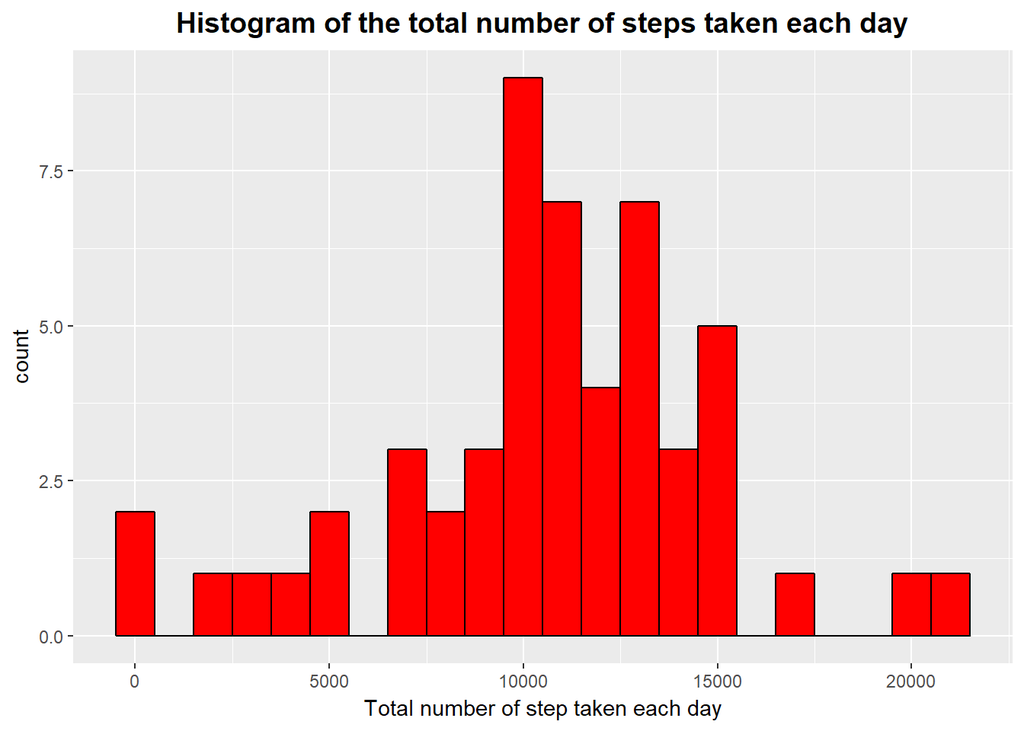

```r
ggplot (data_graph_1, aes (x = value)) + geom_histogram (binwidth = 1000, color = "black", fill= "red") +
        labs (x = "Total number of step taken each day") +
        ggtitle ("Histogram of the total number of steps taken each day") +
        theme (plot.title = element_text (hjust = 0.5, size = 14, face = "bold"))
```

### Mean and median total number of steps taken per day

#### Disable scientific notation

```r
options(scipen=999)

# Compute the results
round (summary (total_number_of_steps)["Mean"], 0)
```

```
##  Mean
## 10766
```

```r
summary (total_number_of_steps)["Median"]
```

```
## Median
##  10765
```

The mean and median of total number of steps taken per day are respectively 10766 and 10765.

### Average daily activity pattern

#### Time series plot of the 5-minute interval and the average number of steps taken, averaged across all days

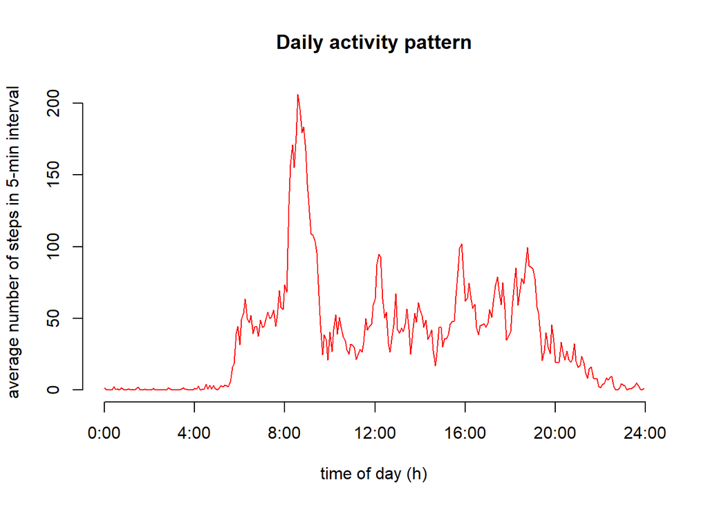

```r
# Compute the mean of steps by each 5-minute interval
average_steps <- tapply (data $ steps, data $ interval, mean, na.rm = T)

# Plot the time series
hours <- as.numeric (names (average_steps)) / 60
plot (hours, average_steps, type="l", axes=F,
     xlab="time of day (h)",
     ylab="average number of steps in 5-min interval",
     main="Daily activity pattern",
     col = "red")
axis(2)
axis(1, at=0:6*4, labels=paste(0:6*4,":00", sep=""))
```

#### Which 5-minute interval, on average across all the days in the dataset, contains the maximum number of steps?

```r
names (max_interval <- which.max (average_steps))
```

```
## [1] "515"
```

```r
max_act_num <- which (average_steps == max (average_steps))
max_act_int <- data $ interval[max_act_num]
sprintf ("%02d:%02d", floor(max_act_int/60), max_act_int %% 60)
```

```
## [1] "08:35"
```

### Imputing missing values

Note that there are a number of days/intervals where there are missing values (coded as NA). The presence of missing days may introduce bias into some calculations or summaries of the data.

#### Calculate and report the total number of missing values in the dataset

```r
sum (is.na (data))
```

```
## [1] 2304
```

```r
# alternative :
colSums (is.na (data))
```

```
##    steps     date interval
##     2304        0        0
```

There are 2304 cells with missing value.

#### Devise a strategy for filling in all of the missing values in the dataset.

```r
mean (data $ steps, na.rm = T)
```

```
## [1] 37.3826
```

#### Create a new dataset that is equal to the original dataset but with the missing data filled in.

```r
data_imputed <- data
data_imputed $ steps [is.na (data_imputed $ steps)] <- mean (data_imputed $ steps, na.rm = T)
summary (data_imputed)
```

```
##      steps             date               interval
##  Min.   :  0.00   Min.   :2012-10-01   Min.   :   0.0
##  1st Qu.:  0.00   1st Qu.:2012-10-16   1st Qu.: 358.8
##  Median :  0.00   Median :2012-10-31   Median : 717.5
##  Mean   : 37.38   Mean   :2012-10-31   Mean   : 717.5
##  3rd Qu.: 37.38   3rd Qu.:2012-11-15   3rd Qu.:1076.2
##  Max.   :806.00   Max.   :2012-11-30   Max.   :1435.0
```

#### Make a histogram of the total number of steps taken each day.

```r
total_number_of_steps_data_imputed <- tapply (data_imputed $ steps, data_imputed $ date, FUN = sum)
```

```r
data_graph_2 <- aggregate (data_imputed $ steps, by = list (Category = data_imputed  $ date), FUN = sum)
colnames (data_graph_2) <- c ("date", "value")
head (data_graph_2)
```

```
##         date    value
## 1 2012-10-01 10766.19
## 2 2012-10-02   126.00
## 3 2012-10-03 11352.00
## 4 2012-10-04 12116.00
## 5 2012-10-05 13294.00
## 6 2012-10-06 15420.00
```

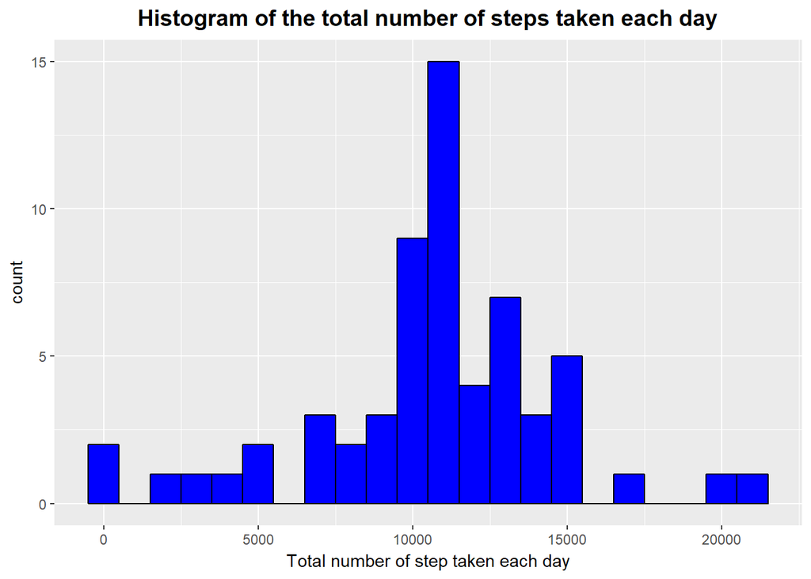

```r
ggplot (data_graph_2, aes (x = value)) + geom_histogram (binwidth = 1000, color = "black", fill="blue") +
        labs (x = "Total number of step taken each day") +
        ggtitle ("Histogram of the total number of steps taken each day") +
        theme (plot.title = element_text (hjust = 0.5, size = 14, face = "bold"))
```

#### Calculate and report the mean and median total number of steps taken per day.

#### Disable scientific notation

```r
round (summary (total_number_of_steps_data_imputed)["Mean"], 0)
```

```
##  Mean
## 10766
```

```r
summary (total_number_of_steps_data_imputed)["Median"]
```

```
##   Median
## 10766.19
```

The mean and median of total number of steps taken per day are respectively 10766 and 10766.1886792.

#### Do these values differ from the estimates from the first part of the assignment?

```r
t.test (total_number_of_steps_data_imputed, total_number_of_steps)
```

```
##
##  Welch Two Sample t-test
##
## data:  total_number_of_steps_data_imputed and total_number_of_steps
## t = 0, df = 107.14, p-value = 1
## alternative hypothesis: true difference in means is not equal to 0
## 95 percent confidence interval:
##  -1539.144  1539.144
## sample estimates:
## mean of x mean of y
##  10766.19  10766.19
```

No, the values do not significantly differ.

#### What is the impact of imputing missing data on the estimates of the total daily number of steps?

```r
sum (data $ steps, na.rm = T)
```

```
## [1] 570608
```

```r
sum (data_imputed $ steps)
```

```
## [1] 656737.5
```

It increases the number of steps of 86130 *id est* by 15%.

### Are there differences in activity patterns between weekdays and weekends?

For this part the weekdays() function may be of some help here. Use the dataset with the filled-in missing values for this part. Create a new factor variable in the dataset with two levels – “weekday” and “weekend” indicating whether a given date is a weekday or weekend day.

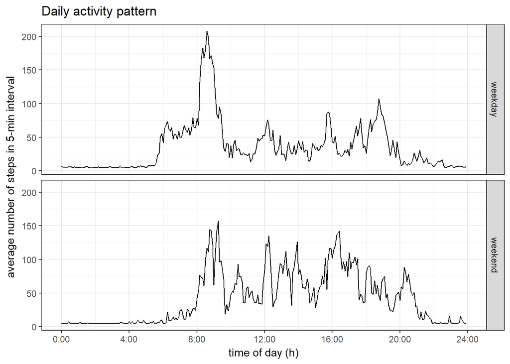

```r
week <- factor (weekdays (data_imputed $ date) %in% c("Saturday", "Sunday"), labels =c("weekday", "weekend"), ordered = FALSE)
data_graph_3 <- aggregate (data_imputed $ steps, by=list (interval = data_imputed $ interval, weekday = week), mean)

g <- ggplot(data_graph_3, aes(interval/60, x))
g + geom_line () + facet_grid (weekday ~ .) +
    scale_x_continuous (breaks=0:6*4, labels=paste(0:6*4,":00", sep="")) +
    theme_bw() +
    labs(y="average number of steps in 5-min interval") +
    labs(x="time of day (h)") +
    labs(title="Daily activity pattern")
```

### References

http://rstudio-pubs-static.s3.amazonaws.com/17469_4fbb71c305ba4a25a40eba1f8cdbb3e9.html  
http://rstudio-pubs-static.s3.amazonaws.com/20832_2d80bc97976b4c29b62313928a82115b.html  
https://rpubs.com/ChrisToJ/22506